# Informe práctico 2

La base de datos `meteoritos` contiene información de impactos de meteoritos y su fuente es la NASA. Incluye información sobre más de 45.000 meteoritos, incluyendo su nombre, ubicación, masa y año de impacto.

### **Parte 1**

**Pregunta:** ¿Cuál es la distribución geográfica de los meteoritos y donde cayeron los más pesados?

**Introducción:** Para responder a la preguntar observamos nuestros conjunto de de datos en relacion a distribucion geografica y el tamaño de los meteoritos para tambien ubicar donde cayeron los mas pesados

Tambien nos interesa investigar la distribucion geografica y su cantidad por continente usamos geom bar para poder representar la cantidad de meterioritos segun su cantinente: hace que la altura del eje “y” siendo la Cantidad sea proporcional al eje “x” su Continente. En este grafico solo los datos nulos de latitud y longitud se omiten ya que se desconoce la ubicacion del meteorito y no se puede saber su continente y los otros datos nulos no interifieren a lo que queremos desmostrar.

**Analisis:**

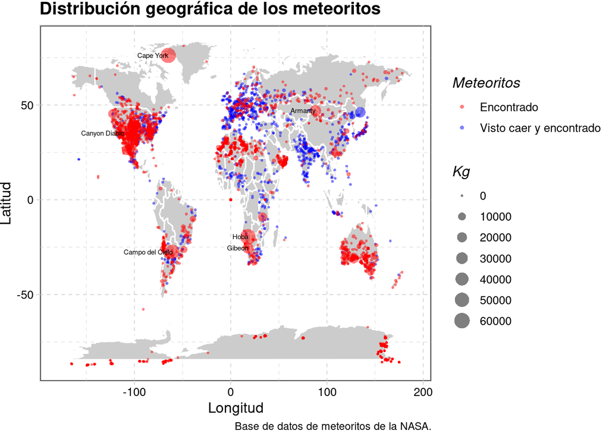

```r
mapa <- map_data("world")



meteoritos_mapa <- meteoritos %>%
    drop_na() %>%
mutate(fall = if_else(str_starts(fall, "Fel"), "Visto caer y encontrado", fall)) %>%
  mutate(fall = if_else(str_starts(fall, "Foun"), "Encontrado", fall))


options(scipen = 999)


ggplot(mapa, aes(x = long, y = lat)) +
  geom_polygon(aes( x= long, y = lat, group = group),fill = "grey80",color = "white") +
  geom_point(data= meteoritos_mapa,
             aes(x=long, y = lat, size = mass/1000, color = fall), stroke = F, alpha = 1/2) +
  geom_text(data = subset(meteoritos_mapa, mass >=26000000), aes(label = name), hjust = 1, nudge_x = 0.2, size = 2)+
  scale_color_manual(values = c( "red", "blue"), name = "Meteoritos") +
  scale_size_continuous(name = "Kg")  +
  theme_pander()+
  theme(panel.background = element_rect(colour= "black", size= 1))+
    labs(title = "Distribución geográfica de los meteoritos"
    ,y = "Latitud",
       x = "Longitud",
       caption = "Base de datos de meteoritos de la NASA.")
```

```r
meteoritos2 <- readr::read_csv("https://raw.githubusercontent.com/rfordatascience/tidytuesday/master/data/2019/2019-06-11/meteorites.csv")
```

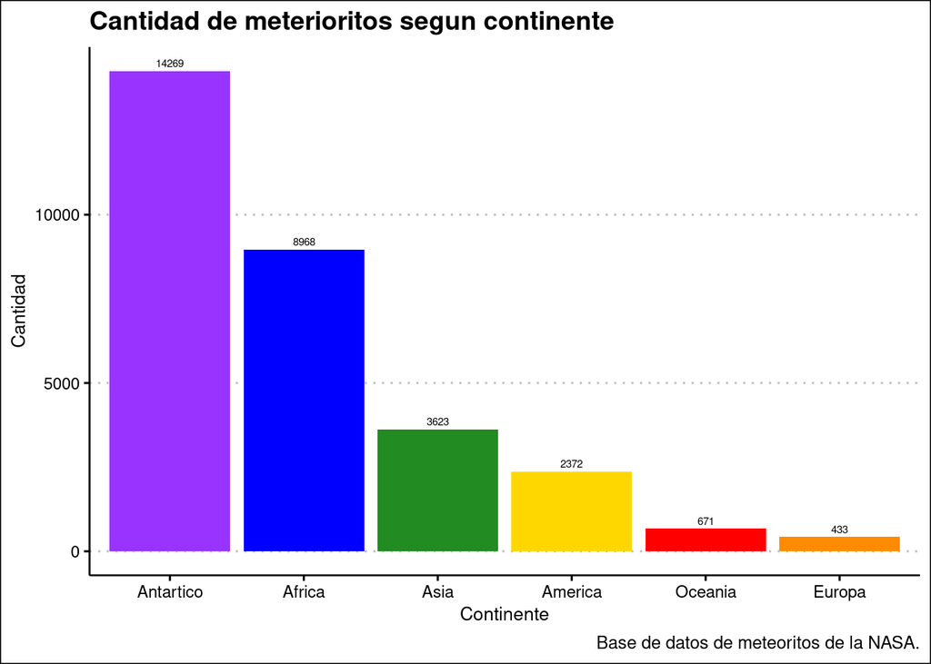

```r
meteoritosfn <- meteoritos2[!is.na(meteoritos2$lat),]
meteoritosfn <- meteoritosfn[!is.na(meteoritosfn$long),]

meteoritos_Europa <- meteoritosfn %>%
  filter(between(long, -12, 25),
         between(lat, 37, 65)) %>%
  arrange(mass)

car<-read.table(header=TRUE,text="
Continente
Europa
")

ContinenteEuropa = cbind(meteoritos_Europa, car)


meteoritos_America <- meteoritosfn %>%
  filter(between(long, -165,-27),
         between(lat, -57,80)) %>%
  arrange(mass)


amv<-read.table(header=TRUE,text="
Continente
America
")

ContinenteAmerica = cbind(meteoritos_America, amv)


meteoritos_Africa <- meteoritosfn %>%
  filter(between(long, -30,50),
         between(lat, -60,31)) %>%
  arrange(mass)

cnf<-read.table(header=TRUE,text="
Continente
Africa
")

ContinenteAfricano = cbind(meteoritos_Africa, cnf)



meteoritos_Antartida <- meteoritosfn %>%
  filter(between(long, -140, 160),
         between(lat, -85, -60)) %>%
  arrange(mass)


cna<-read.table(header=TRUE,text="
Continente
Antartico
")

ContinenteAntartico = cbind(meteoritos_Antartida, cna)


meteoritos_oceania <- meteoritosfn %>%
  filter(between(long, 70,180),
         between(lat, -45,-5)) %>%
  arrange(mass)


cao<-read.table(header=TRUE,text="
Continente
Oceania
")

ContinenteOceanico = cbind(meteoritos_oceania, cao)



meteoritos_asia <- meteoritosfn %>%
  filter(between(long, 45,160),
         between(lat, -5,80)) %>%
  arrange(mass)


cas<-read.table(header=TRUE,text="
Continente
Asia
")

ContinenteAsia = cbind(meteoritos_asia, cas)



df_union<-merge(ContinenteAsia,ContinenteOceanico,all=TRUE)
df_union1<-merge(df_union, ContinenteAntartico,all=TRUE)
df_union2<-merge(df_union1, ContinenteAfricano,all=TRUE)
df_union3<-merge(df_union2, ContinenteAmerica,all=TRUE)
df_union4<-merge(df_union3, ContinenteEuropa,all=TRUE)


meteorites23 <- df_union4 %>%
  group_by(Continente) %>%
  summarise(
    count = n()) %>%
  arrange(desc(count))


ggplot(meteorites23) +
  geom_bar(aes(x = fct_relevel(Continente, "Antartico", "Africa", "Asia", "America", "Oceania", "Europa"), y = count),
    stat='identity', position = 'dodge', fill = c("#9933FF", "Blue", "Forest Green","Gold","red","Dark Orange")) +
  geom_text(
    aes(x = Continente, y = count, label = count),
    position = position_dodge(width = 1),
    vjust = -0.5, size = 2
  ) +
  theme_clean() +
    labs(title = "Cantidad de meterioritos segun continente"
    ,y = "Cantidad",
       x = "Continente",
       caption = "Base de datos de meteoritos de la NASA.")
```

**Discusión:** Comenzamos nuestro análisis: Podemos observar que que el meteorito mas pesado en encuentra en Africa y los segundos mas grande en America. Siendo el contiente Americano el que posee mayor cantidad de meteoritos mas pesados por contiente. Si analizamos la cantidad America la mayor parte de meterioritos fueron encontrados al igual que Antartida, Oceania en Europa y Asia varia un poco mas y en la India es un caso curiosio ya que la mayoria de meterioritos se vio caer y fueron encontrados

Tambien el continente que mas meterioritos encontrados tiene es la Antarctica con 14269 metioritos y el menor Europa con 433 metioritos.

### **Parte 2**

**Pregunta:** ¿Cuales son las cinco clases mas frencuentes a partir del 2000 hasta el 2011?

**Introducción:** Para poder responder a la pregunta debemos observar nuestro conjunto de datos en relacion en la cantidad meteoritos segun su clase y su año para estudiar su crecimiento, podemos observamos la evolución de estos meteoritos segun clase desde sus comienzos en 2000 hasta la 2011 y como fue variando a lo largo del tiempo

**Enfoque:** Empleamos los graficos de columnas ya que hace que las alturas de las barras representen las cantidad e los meteoritos en los datos para realizar el análisis, caracterizando la estructura mediante magnitudes como la cantidad de meteoritos y el año segun clase.

**Analisis:**

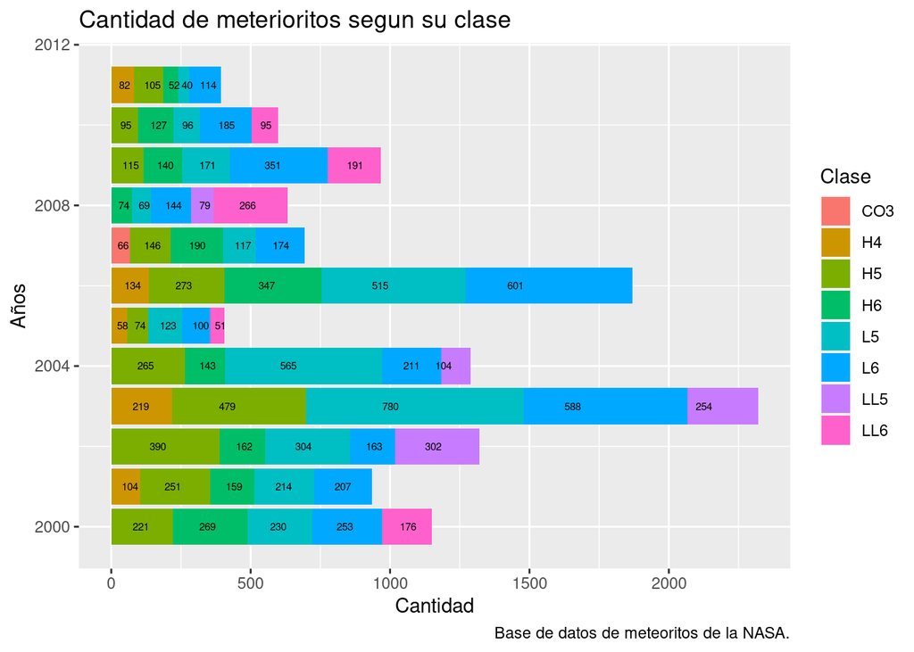

```r
top<-meteoritos %>%
  subset(year >= 2000 & year <= 2011) %>%
  group_by(year, class)   %>%
  count(class) %>%
  group_by(year) %>%
  mutate(rank = rank(-n),
         value_lbl = paste0("", n)) %>%
  group_by(class) %>%
  filter(rank <=5) %>%
  ungroup()





ggplot(top, aes(x = year, y = n)) +
  geom_col(aes(fill = class), position = position_stack(reverse = TRUE))+
coord_flip()+
     geom_text(size =2, aes(label = n), hjust = "inward", position = position_stack(vjust = 0.35, reverse = TRUE))+
    labs(title = "Cantidad de meterioritos segun su clase"
    ,y = "Cantidad",
       x = "Años",
       caption = "Base de datos de meteoritos de la NASA.",
    fill = "Clase")
```

```r
test<-meteoritos%>%
          mutate(year = as.character(year)) %>%
          subset(year >= 2000 & year < 2011) %>%
          group_by(year,class) %>%
          count(class) %>%
          group_by(year)%>%
          mutate(rank=rank(-n),
                 value_lbl=paste0("",n)) %>%
          group_by(class) %>%
          filter(rank <=1) %>%
          ungroup()


tb2w <-test %>%
  select(class, n, year) %>%
  arrange(desc(year))


tb2 <-
  kable(tb2w,caption = '<strong><p style="color:#000000";>Clase mas popular segun año</p></strong>', format = 'html',col.names = c("Clase", "Cantidad", "Año"),
        format.args = list(decimal.mark = ",", big.mark = "."))


#tb2 %>%
#  row_spec(row = 0, underline = TRUE) %>%
#  collapse_rows(columns = 1, valign = "top")  %>%
#  kable_styling()
```